# Aula 6 - Regressão Linear

PPEC

Ensino

Estatística

Neste notebook realizamos uma análise de regressão linear para dados de calibração de equipamentos de geotecnia.

Published

June 28, 2026

[figure not shown]

2b7c8f05-15ab-4b0c-889c-1010d8b5f17a.jfif

**O uso da regressão linear para calibração de equipamentos de Geotecnia.**

**Discente**: Welkens Oliveira

**Disciplina**: Estatística e Planejamento de experimentos - PPEC-0039

**Objetivo:** Descrever o uso da regressão linear em experimentos da pesquisa em Geotecnia

**Introdução**

Antes de entender o que é a regressão linear, é necessário abordar algumas conceitos:

- **Variável dependente (y)**: trata-se do “efeito” ou resultado na análise de algum fenômeno;
- **Variável independente (x)**: é a causa ou fator explicativo, é aquilo que se observa/manipula para ver o impacto que causa;
- **Correlação**: indica a força e direção (diretamente ou inversamente) com que 2 variáveis se relacionam;

Com base nos conceitos apresentados acima, diz-se que o conceito de regressão linear é a aplicação de um modelo que explique a relação linear entre a variável dependente e a variável independente, de forma que essa correlação entre as variáveis pode ser positiva (diretamente proporcional, +1) ou negativa (inversamente proporcional, -1).

Segue um exemplo simples de um conjunto de dados com correlação positiva, ou seja, os dados são diretamente proporcionais. A variável dependente (nota) e a variável independente (horas de estudo) são duas grandezas proporcionais em que a medida que as horas de estudo aumentam, a nota também aumenta.

```python
import matplotlib.pyplot as plt

horas = [2, 4, 6, 7, 9, 10, 12]
notas = [3.5, 5.0, 6.8, 7.5, 8.2, 9.0, 10.0]

plt.scatter(horas, notas, color='blue', label='Desempenho Alunos')
plt.title('Dispersão: Horas de Estudo vs Nota')
plt.xlabel('Horas de Estudo')
plt.ylabel('Nota da Prova')
plt.grid(True, linestyle='--')
plt.show()
```

[figure not shown]

Por outro lado, um conjunto de dados com correlação negativa indica que há um relação inversamente proporcional das grandezas. Um exemplo dessa dinâmica pode ser observado no gráfico abaixo em que a variável independente(altitude) aumenta a variável dependente (pressão atmosférica) diminui.

```python
import matplotlib.pyplot as plt
import numpy as np

# Dados simulados: Altitude (metros) vs Pressão Atmosférica (kPa)
altitude = np.array([0, 500, 1000, 1500, 2000, 2500, 3000, 3500, 4000, 4500, 5000])
pressao = np.array([101.3, 95.4, 89.8, 84.5, 79.4, 74.6, 70.1, 65.7, 61.6, 57.7, 54.0])

# Configuração da figura
plt.figure(figsize=(10, 6))

# Plotagem dos pontos (Dispersão)
plt.scatter(altitude, pressao, color='darkblue', s=50, label='Medições de Pressão')

# Linha de tendência para destacar a proporcionalidade inversa
z = np.polyfit(altitude, pressao, 2) # Ajuste polinomial para melhor representar a curva física
p = np.poly1d(z)
altitude_lin = np.linspace(altitude.min(), altitude.max(), 100)
plt.plot(altitude_lin, p(altitude_lin), "r-", linewidth=2, label='Tendência Inversa')

# Formatação Técnica
plt.title('Relação Inversamente Proporcional: Altitude vs. Pressão', fontsize=14)
plt.xlabel('Altitude (m)', fontsize=12)
plt.ylabel('Pressão Atmosférica (kPa)', fontsize=12)
plt.grid(True, linestyle=':', alpha=0.7)
plt.legend()

# Exibição
plt.tight_layout()
plt.show()
```

[figure not shown]

**Modelo de regressão linear simples**

O MRLS ou simplesmente regresão é o modelo que define essa relação linear entre a variável dependepente e a variável independente.

**O MRLS na prática geotécnica**

Quando se trabalha com equipamentos no geral, é essencial que tais equipamentos apresentem um certo grau de confiabilidade dos resultados. Do ponto de vista da calibração, os equipamentos além de precisos (repetibilidade) eles precisam ser acurados (medir o valor correto). Esses dois conceitos estão relacionados ao quão confiável os resultados medidos estão perto do valor real. Na prática geotécnica, principalmente, nos ensaios de laboratório é comum o uso de modelos de regressao linear para calibração de equipamentos.

A imagem abaixo ilustra exatamente os conceitos apresentados acima:

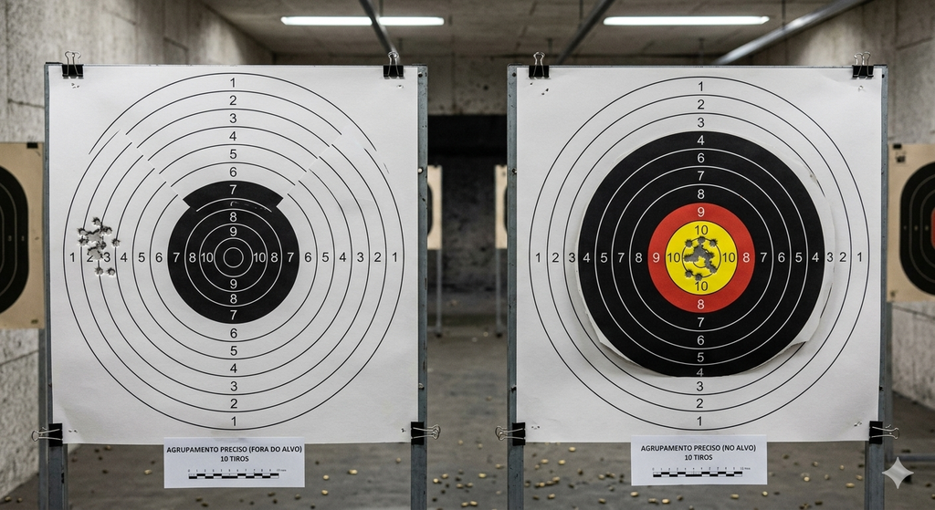

Gemini_Generated_Image_quv0t9quv0t9quv0.png

Um equipamento pode ter repetibilidade mas não ser acurado. Ser acurado refere-se a acertar o mais próximo possível do alvo. Portanto, quando se fala na confiabilidade dos dados gerados por equipamentos é preciso que tais equipamentos estejam calibrados. Umas das formas de se calibrar um equipamento é por meio de um modelo de regressão linear.

**Contexto:** Na atividade proposta solicitou-se que fossem verificadas a acurácia e a precisão de dois equipamentos do Laboratório de Geotecnia Ambiental – GEOAMB. O primeiro equipamento é um **transdutor de deslocamento** (LVDT) e o segundo equipamento é um **transdutor de pressão**. Para aferir se um equipamento está preciso e acurado é necessário comparar o equipamento desejado com um equipamento de referência que geralmente já acreditado por empresas de calibração, portanto usa-se o equipamento de referência para calibrar outros equipamentos. No caso do transdutor de deslocamento o equipamento de referência é um micrômetro, já para o transdutor de pressão o equipamento de referência é um manômetro

**Método de coleta dos dados do LVDT:** na extremidade do micrômetro está conectada ao LVDT e qualquer deslocamento provocado no micrômetro irá ocasionar um deslocamento no LVDT, que por sua vez, tal deslocamento é lido pelo sistema. O micrômetro é o equipamento de referência e o LVDT o equipamento a ser verificado.

```python
import numpy as np
import matplotlib.pyplot as plt
from scipy import stats

# 1. Dados extraídos da imagem
x = np.array([0, 0.5, 1, 1.5, 2, 2.5])
y = np.array([6.683, 7.31, 7.891, 8.437, 8.961, 9.467])

# 2. Cálculo da regressão linear
# slope = coeficiente angular, intercept = coeficiente linear
# r_value = coeficiente de correlação (r)
slope, intercept, r_value, p_value, std_err = stats.linregress(x, y)

# Cálculo do R² (Coeficiente de determinação)
r_squared = r_value**2

# 3. Criação da reta ajustada
y_pred = slope * x + intercept

# 4. Formatação da legenda da equação
texto_ajuste = f'Equação: y = {slope:.4f}x + {intercept:.4f}\n$R^2$ = {r_squared:.4f}'

# 5. Plotagem
plt.figure(figsize=(9, 6))
plt.scatter(x, y, color='darkorange', label='Dados Experimentais', s=80, edgecolors='k')
plt.plot(x, y_pred, color='navy', linestyle='--', linewidth=2, label='Ajuste Linear')

# Adicionando o texto da equação e R² dentro do gráfico
# Os parâmetros 0.05 e 0.95 posicionam o texto proporcionalmente aos eixos (transform=ax.transAxes)
plt.gca().text(0.05, 0.92, texto_ajuste, transform=plt.gca().transAxes,
               fontsize=11, verticalalignment='top', bbox=dict(boxstyle='round', facecolor='white', alpha=0.5))

# Configurações estéticas
plt.xlabel('x (cm)', fontsize=12)
plt.ylabel('y (cm)', fontsize=12)
plt.title('Análise de Deslocamento: Regressão Linear', fontsize=14)
plt.legend(loc='lower right')
plt.grid(True, which='both', linestyle=':', alpha=0.6)

plt.show()

# Exibição no console para conferência
print(f"Equação: y = {slope:.4f}x + {intercept:.4f}")
print(f"R²: {r_squared:.4f}")
```

[figure not shown]

```
Equação: y = 1.1097x + 6.7378
R²: 0.9984
```

```python
import numpy as np
import matplotlib.pyplot as plt
from scipy import stats

# 1. Entrada de dados (extraídos do Quadro 2)
x = np.array([0, 100, 200, 300, 400, 500, 600])
y = np.array([-1.8, 117.3, 218.4, 323.7, 426.8, 523.3, 631.6])

# 2. Execução da Regressão Linear
slope, intercept, r_value, p_value, std_err = stats.linregress(x, y)
r_squared = r_value**2

# 3. Cálculo dos valores da reta para o gráfico
y_pred = slope * x + intercept

# 4. Configuração da Visualização
plt.figure(figsize=(10, 6))
plt.scatter(x, y, color='red', label='Dados Experimentais (kPa)', s=50, edgecolors='black')
plt.plot(x, y_pred, color='blue', label='Reta de Ajuste Linear', linewidth=2)

# Adicionando a Equação e o R² no gráfico
texto_resultados = f'Equação: y = {slope:.4f}x + ({intercept:.4f})\n$R^2 = {r_squared:.4f}$'
plt.gca().text(0.05, 0.90, texto_resultados, transform=plt.gca().transAxes,
               fontsize=12, verticalalignment='top',
               bbox=dict(boxstyle='round', facecolor='white', alpha=0.6))

# Títulos e legendas
plt.title('Ajuste Linear: Coleta de Dados de Pressão Neutra', fontsize=14)
plt.xlabel('Pressão X (kPa)', fontsize=12)
plt.ylabel('Pressão Y (kPa)', fontsize=12)
plt.legend(loc='lower right')
plt.grid(True, linestyle='--', alpha=0.7)

plt.show()

# Exibição dos coeficientes no terminal
print(f"--- Resultados do Ajuste ---")
print(f"Coeficiente Angular (m): {slope:.4f}")
print(f"Coeficiente Linear (b):  {intercept:.4f}")
print(f"R²: {r_squared:.4f}")
```

[figure not shown]

```
--- Resultados do Ajuste ---
Coeficiente Angular (m): 1.0431
Coeficiente Linear (b):  6.9786
R²: 0.9994
```

**Conclusões Gerais:** A relação linear e o ajuste são obtidos ao plotar o equipamento de referência no eixo x e o equipamento a ser verificado no eixo y, busca-se assim uma curva de calibração que se comporta como a regressão linear simples:

𝑦=𝑎𝑥+𝑏

Em que o **a** (coeficiente angular da reta) indica a sensibilidade do equipamento e caso o equipamento que se deseja calibrar em comparação ao equipamento de referência o a será igual a 1, ou seja para uma variação em x=100, y também deverá variar 100 e para isso o coeficiente angular (a) deve ser aproximadamente 1. O **R²** por sua vez mede a qualidade do ajuste, ou seja, o quão próximos os resultados obtidos estão próximos do valor do ajuste, consequente o R² é uma medida que reflete o grau de repetibilidade do equipamento. Quanto mais próximo de 1 R² está mais repetibilidade o equipamento tem, em outras palavras, o equipamento está obtendo resultados muito próximos uns dos outros e apesar de não indicar, por si só a acurácia do equipamento, pelo menos, indica que o equipamento está pronto para obter resultados coerentes depois de calibrado.

**Dessa forma, pode-se atestar a importância do uso da regressão linear como um instrumento de ajuste para calibração de equipamento.**